# Reguły asocjacyjne - zadanie zaliczeniowe

Adam Kacprzycki - studia podyplomowe DS - PW Data mining - ed.11 (21L)- grupa I

**CEL EKSPERYMENTU I ODPOWIEDZ NA PYTANIA:**

1. Do czego potencjalnie w praktyce mogą być wykorzystane odkryte reguły:

Odkryte reguły w kontekście analizowanych danych dot. zbioru “Groceries”, potencjalnie mogą zostać zastosowane do:  
- zwiększenie sprzedaży towarów poprzez zastosowanie odpowiedniej strategii rabatowej lub promocyjnej (np. do produktu X kup produkt Y za cenę …, z rabatem itd.),  
- ustalenie odpowiedniej polityki rabatowej, promocyjnej (może okazać się, że należy przydzielić rabat wyłącznie na jeden produkt, aby go sprzedać razem z innymi produktami),  
- na podstawie danych historycznych zebranych per klient w ramach programu lojalnościowego (np. karta klienta w Żabce), można przesłać do klienta spersonalizowaną ofertę zakupową/rabatową lub reklamową i tym samym zachęcić klienta do kupna określonych produktów (np. kupiłeś produkt X to następnym razem kup może też Y …)  
- możliwość odpowiedniej aranżacji i organizacji powierzchni handlowej (całych alejek sklepowych wraz z półkami itd) w celu maksymalizacji sprzedaży,  
- zestawianie produktów w zestawy, kup w zestawie produkt X i Y za cenę …

2. Jaka reguła jest interesująca (definicja na bazie dostępnych parametrów reguł):

Zakwalifikowałem jako ciekawe, następujące reguły:  
- LHS(onions,butter) -> RHS(whole milk) support: 0.0030503 confidence: 0.75000 lift: 2.9352 certainty: 0.66420  
- LHS(tropical fruit,root vegetables,whipped/sour cream) -> RHS(other vegetables) support: 0.0034 confidence: 0.73333 lift 3.7900 count(“koszyki”) 33 certainty: 0.66936  
- LHS(citrus fruit,tropical fruit,root vegetables,whole milk) -> RHS(other vegetables) support: 0.0032 confidence: 0.88571 lift: 4.5775, count(“koszyki”): 31 certainty: 0.8583  
UWAGA: *OPIS REGUŁ I DOKANANEGO WYBORU PONIŻEJ.

3. Jak wybrać najlepszą regułę.

W mojej ocenie, odpowiedź może być skomplikowana i uwarunkowana jest indywidualnymi potrzebami klienta, biznesu lub danego projektu. Jeżeli mamy do czynienia z firmą z branży handlu detalicznego, jednym z celów w ramach poszukiwania reguł asoscjacyjnych może być maksymalizacja ogólnej sprzedaży. Tym samym wybór najlepszej reguły może opierać się o miary oceny jakości dla których znajdziemy najlepszą możliwą konfigurację maksymalnie wysokiego poziomu zaufania (powyżej 0.5 bliżej >=0.8) i wsparcia (kwestia indywidualna) dla których będziemy mieli współczynnik podniesienia >1, a współczynnik pewności będzie większy od 0 co świadczyć będzie o tym że elementy reguły są zależne pozytywnie.

Zgodnie z powyższymi kryteriami, wybrałem następującą regułe jako najlepszą: - LHS (citrus fruit,tropical fruit,root vegetables) => RHS (other vegetables) support 0.0044738 confidence 0.78571 lift 4.0607 count(“koszyki”) 44 certainty 0.73430.

UWAGA: *OPIS REGUŁY I DOKANANEGO WYBORU PONIŻEJ.

**I. ANALIZA I WYSZUKANIE REGUŁ**

Analizowany będzie zbiór danych z pakietu arules -> Groceries.

Zaimportowanie wykorzystywanych bibliotek, danych oraz zapoznanie się z specyfiką danych:

```r
library(arules)
```

```r
library(arulesViz)
library(ggplot2)

data('Groceries')

?Groceries

#Dane transakcyjne sklepu dyskontowego (profil: spożywczy, retail) z 30 dni. Ilość transakcji/koszyków 9835 (średnio 327 dziennie), dane produktowe zagregowane do 169 kategorii (np. saugage > meat and sausages itd).
```

**II. WSTĘPNA ANALIZA DANYCH**

1. Szybki wgląd w analizowane dane przy pomocy funkcji summary():

```r
summary(Groceries)
```

```
## transactions as itemMatrix in sparse format with
##  9835 rows (elements/itemsets/transactions) and
##  169 columns (items) and a density of 0.02609146
##
## most frequent items:
##       whole milk other vegetables       rolls/buns             soda
##             2513             1903             1809             1715
##           yogurt          (Other)
##             1372            34055
##
## element (itemset/transaction) length distribution:
## sizes
##    1    2    3    4    5    6    7    8    9   10   11   12   13   14   15   16
## 2159 1643 1299 1005  855  645  545  438  350  246  182  117   78   77   55   46
##   17   18   19   20   21   22   23   24   26   27   28   29   32
##   29   14   14    9   11    4    6    1    1    1    1    3    1
##
##    Min. 1st Qu.  Median    Mean 3rd Qu.    Max.
##   1.000   2.000   3.000   4.409   6.000  32.000
##
## includes extended item information - examples:
##        labels  level2           level1
## 1 frankfurter sausage meat and sausage
## 2     sausage sausage meat and sausage
## 3  liver loaf sausage meat and sausage
```

```r
#itemInfo(Groceries) #informacje dotyczące hierarchi i przynależności produktów do danej kategorii
#inspect(Groceries[1:1]) #wgląd w pierszą transakcję
```

Podsumowanie:

W analizowanym zestawie danych mamy: - 9835 transakcji (“koszyków zakupowych”) oraz 169 unikalnych produktów. - najczęściej występującym produktem było pełne mleko (ang. whole milk). - około 21% (ilościowo: 2159 szt.) stanowiły transakcje, w których zakupiony został tylko jeden produkt. - najwięcej w produktów tj. 32 szt. zawierała tylko jedna transakcja. - średnia wielkość koszyka to: 4.409 szt.

2. Sprawdzam jakie produkty występują przynajmniej w 5% transakcji (support = 0.05) i tym samym, które produkty cieszą się największym zainteresowaniem (najszybciej rotują):

Produktów ze wsparciem >= 5%:

```r
supportlvl = 0.05
freqGros <- itemFrequency(Groceries)

freqGros5 <- sort(freqGros[freqGros>=0.05], decreasing = T)
length(freqGros5) #jest 28 produktów ze wsparciem 5%.
```

```
## [1] 28
```

```r
head(freqGros5, n = 10) # wyświetlam pierwsze 10 wyników
```

```
##       whole milk other vegetables       rolls/buns             soda
##       0.25551601       0.19349263       0.18393493       0.17437722
##           yogurt    bottled water  root vegetables   tropical fruit
##       0.13950178       0.11052364       0.10899847       0.10493137
##    shopping bags          sausage
##       0.09852567       0.09395018
```

Top 5 produkty to: 1. whole milk, 2. other vegetables, 3) rolls/buns, 4)soda, 5)yogurt.

Wykres słupkowy - czestość względna produktów:

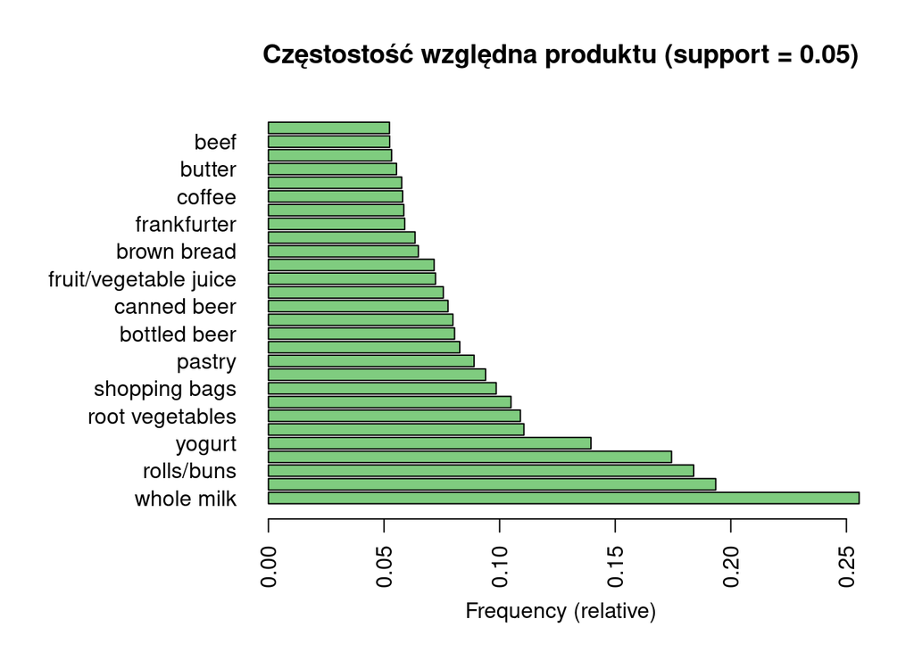

```r
itemFrequencyPlot(Groceries,
                  topN = length(freqGros5),
                  col=rgb(0,0.6,0,0.5),
                  horiz = TRUE,
                  xlab="Frequency (relative)",
                  main="Częstostość względna produktu (support = 0.05)")
```

Wykres słupkowy czestość bezwzględna - ilość wystąpień w szt. produktów w tramsakcjach:

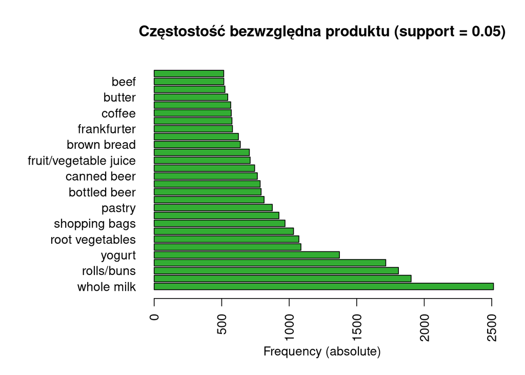

```r
itemFrequencyPlot(Groceries,
                  topN = length(freqGros5),
                  type = "absolute",
                  col=rgb(0,0.6,0,0.8),
                  horiz = TRUE,
                  xlab="Frequency (absolute)",
                  main="Częstostość bezwzględna produktu (support = 0.05)")
```

**III. WYBÓR POZIOMU WSPARCIA ORAZ ZAUFANIA DLA ALGORYTMU APRIORI:**

Pierwszym krokiem, w zakresie określenia zestawu reguł asocjacyjnych będzie ustalenie optymalnych i uzasadnionych wartości wsparcia oraz zaufania. Należy pamiętać, że ustalenie zbyt niskich wartości może wydłużać czas wykonania algorytmu oraz spowodować otrzymanie zbyt wielu reguł, z których większość z nich nie będzie przydatna. W tym celu przeprowadzę eksperyment dla różnych kombinacji ww. wartości parametrów i sprawdzę, ile zostanie utworzonych reguł w ramach algorytmu Apriori.

1. Eksperyment - testowanie poszczególnych wartości support oraz confidence, a liczba otrzymanych reguł algorytmu Apriori:

```r
# Zaproponowane wartości support i confidence do przetestowania:
supportLvl <- c(0.1, 0.05, 0.01, 0.005, 0.003)
confidenceLvl <- c(0.9, 0.8, 0.7, 0.6, 0.5, 0.4, 0.3, 0.2, 0.1)
confVectLen <- length(confidenceLvl)

# Zmienne do wyliczenia liczności reguł dla poszczególnych parametrów support oraz confidence:
rules_sup10 <- integer(length = confVectLen)
rules_sup5 <- integer(length = confVectLen)
rules_sup1 <- integer(length = confVectLen)
rules_sup0.5 <- integer(length = confVectLen)
rules_sup0.3 <- integer(length = confVectLen)

# Wyliczenia
for (i in 1:length(confidenceLvl)) {

  #poziom wsparcia na poziomie 0.1
  rules_sup10[i] <- length(apriori(Groceries, parameter=list(sup=supportLvl[1],
                                   conf=confidenceLvl[i], target="rules", minlen =2)))
  #poziom wsparcia na poziomie 0.05
  rules_sup5[i] <- length(apriori(Groceries, parameter=list(sup=supportLvl[2],
                                  conf=confidenceLvl[i], target="rules", minlen =2)))
  #poziom wsparcia na poziomie 0.01
  rules_sup1[i] <- length(apriori(Groceries, parameter=list(sup=supportLvl[3],
                                  conf=confidenceLvl[i], target="rules", minlen =2)))
  #poziom wsparcia na poziomie 0.005
  rules_sup0.5[i] <- length(apriori(Groceries, parameter=list(sup=supportLvl[4],
                                    conf=confidenceLvl[i], target="rules", minlen =2)))
  #poziom wsparcia na poziomie 0.003
  rules_sup0.3[i] <- length(apriori(Groceries, parameter=list(sup=supportLvl[5],
                                    conf=confidenceLvl[i], target="rules", minlen =2)))
}
```

2. Tabelaryczna prezentacja wyników eksperymentu z dobieraniem poszczególnych wartości support oraz confidence, a ilość otrzymanych reguł w ramach algorytmu Apriori:

```r
# Ramka/macierz - ilość reguł uzależniona od wartości support oraz confidence:
num_rules_matrix <- data.frame(confidenceLvl, rules_sup10, rules_sup5, rules_sup1, rules_sup0.5,rules_sup0.3)

num_rules_matrix
```

| confidenceLvl | rules_sup10 | rules_sup5 | rules_sup1 | rules_sup0.5 | rules_sup0.3 |
| --- | --- | --- | --- | --- | --- |
| 0.9 | 0 | 0 | 0 | 0 | 0 |
| 0.8 | 0 | 0 | 0 | 0 | 1 |
| 0.7 | 0 | 0 | 0 | 1 | 19 |
| 0.6 | 0 | 0 | 0 | 22 | 120 |
| 0.5 | 0 | 0 | 15 | 120 | 421 |
| 0.4 | 0 | 1 | 62 | 270 | 823 |
| 0.3 | 0 | 3 | 125 | 482 | 1361 |
| 0.2 | 0 | 6 | 231 | 872 | 2245 |
| 0.1 | 0 | 6 | 427 | 1574 | 3922 |

Wnioski:

Zgodnie z przypuszczeniami dla wyższych poziomów wsparcia oraz zaufania mamy niewielką liczbę reguł lub ich brak. Można zauważyć, że dla wsparcia na poziomie 0.1 nie znaleziono żadnych reguł, niestety przy poziomie wsparcia wynoszącym 0.05 wyniki nadal nie są satysfakcjonujące, ponieważ reguły charakteryzują się niską wartością zaufania poniżej wartości 0.5.

W konsekwencji rozsądnym wyborem wydaje się ustalenie minimalnego poziomu wsparcia uzależnionego od min. satysfakcjonującego nas poziomu zaufania (> 0.5 bliżej wartości 0.8) lub liczby koszyków, dla których istnieją reguły. Generalnie pożądaną sytuacją byłoby wygenerowanie reguł o możliwie jak najwyższym poziomie zaufania przy relatywnie wysokim poziomie wsparcia i występowaniu zależności pozytywnej między poprzednikiem a następnikiem reguły.

Mając na uwadze powyższe, zdecydowałem się analizować dalej reguły o min. wsparciu 0.003, oraz poziomie zaufania min. 0.7.

3. Wybrane parametry algorytmy Apriori, poniżej:

```r
#Wybrane wartości wsparcia oraz zaufania:
supportToUse = 0.003
confidenceToUse = 0.7
minlen = 2
#maxlen = 4
```

3. Algorytm Apriori - odkrywanie reguł
1. Wygenerowanie reguł przy pomocy algorytmu apriori:

```r
rulesApriori <-apriori(Groceries,
                       parameter =
                         list(sup=supportToUse,
                              conf=confidenceToUse,
                              target="rules",
                              minlen =2))
```

```
## Apriori
##
## Parameter specification:
##  confidence minval smax arem  aval originalSupport maxtime support minlen
##         0.7    0.1    1 none FALSE            TRUE       5   0.003      2
##  maxlen target  ext
##      10  rules TRUE
##
## Algorithmic control:
##  filter tree heap memopt load sort verbose
##     0.1 TRUE TRUE  FALSE TRUE    2    TRUE
##
## Absolute minimum support count: 29
##
## set item appearances ...[0 item(s)] done [0.00s].
## set transactions ...[169 item(s), 9835 transaction(s)] done [0.00s].
## sorting and recoding items ... [136 item(s)] done [0.00s].
## creating transaction tree ... done [0.00s].
## checking subsets of size 1 2 3 4 5 done [0.01s].
## writing ... [19 rule(s)] done [0.00s].
## creating S4 object  ... done [0.00s].
```

```r
options(digits = 5)
inspect(rulesApriori)
```

```
##      lhs                     rhs                  support confidence  coverage   lift count
## [1]  {yogurt,
##       baking powder}      => {whole milk}       0.0032537    0.71111 0.0045755 2.7830    32
## [2]  {onions,
##       butter}             => {whole milk}       0.0030503    0.75000 0.0040671 2.9352    30
## [3]  {domestic eggs,
##       sugar}              => {whole milk}       0.0035587    0.71429 0.0049822 2.7955    35
## [4]  {butter,
##       coffee}             => {whole milk}       0.0033554    0.70213 0.0047789 2.7479    33
## [5]  {butter,
##       curd}               => {whole milk}       0.0048805    0.71642 0.0068124 2.8038    48
## [6]  {curd,
##       domestic eggs}      => {whole milk}       0.0047789    0.73438 0.0065074 2.8741    47
## [7]  {pork,
##       butter}             => {whole milk}       0.0038638    0.70370 0.0054906 2.7540    38
## [8]  {tropical fruit,
##       curd,
##       yogurt}             => {whole milk}       0.0039654    0.75000 0.0052872 2.9352    39
## [9]  {root vegetables,
##       other vegetables,
##       brown bread}        => {whole milk}       0.0031520    0.77500 0.0040671 3.0331    31
## [10] {tropical fruit,
##       butter,
##       yogurt}             => {whole milk}       0.0033554    0.73333 0.0045755 2.8700    33
## [11] {root vegetables,
##       butter,
##       yogurt}             => {whole milk}       0.0030503    0.78947 0.0038638 3.0897    30
## [12] {other vegetables,
##       whipped/sour cream,
##       domestic eggs}      => {whole milk}       0.0035587    0.70000 0.0050839 2.7396    35
## [13] {tropical fruit,
##       root vegetables,
##       whipped/sour cream} => {other vegetables} 0.0033554    0.73333 0.0045755 3.7900    33
## [14] {tropical fruit,
##       yogurt,
##       whipped/sour cream} => {whole milk}       0.0043721    0.70492 0.0062023 2.7588    43
## [15] {citrus fruit,
##       tropical fruit,
##       root vegetables}    => {other vegetables} 0.0044738    0.78571 0.0056940 4.0607    44
## [16] {tropical fruit,
##       root vegetables,
##       yogurt}             => {whole milk}       0.0056940    0.70000 0.0081342 2.7396    56
## [17] {citrus fruit,
##       tropical fruit,
##       root vegetables,
##       other vegetables}   => {whole milk}       0.0031520    0.70455 0.0044738 2.7573    31
## [18] {citrus fruit,
##       tropical fruit,
##       root vegetables,
##       whole milk}         => {other vegetables} 0.0031520    0.88571 0.0035587 4.5775    31
## [19] {tropical fruit,
##       root vegetables,
##       other vegetables,
##       yogurt}             => {whole milk}       0.0035587    0.71429 0.0049822 2.7955    35
```

Zgodnie z wcześniejszymi wyliczeniami w sekcji III.2 otrzymałem w ramach zadanych parametrów support 0.003 oraz confidence 0.7 - 19 reguł.

2. Sprawdzenie czy mamy reugły nadmiarowe (redundantne) i w przypadku ich wystpowania usunięcie ich.

```r
inspect(rulesApriori[is.redundant(rulesApriori)])
```

Brak reguł nadmiarowych.

```r
#usunięcie niepotrzebnych reguł o ile występują
rulesApriori <- rulesApriori[is.redundant(rulesApriori) == FALSE]
```

3. Sprawdzenie czy poprzednik z następnikiem są zależne pozytywnie przy pomocy wskaźnika certainty factor:

```r
itemsNo <- length(rulesApriori)

addMeasureApriori <- interestMeasure(rulesApriori,"certainty")
intres <- which(sapply(addMeasureApriori, function(x) {x > 0  && x <= 1})==TRUE)

intersRule <- length(rulesApriori[intres])
ans <- (intersRule == itemsNo)
cat("Czy wszystkie reguły mają współcynnik pewności powyżej 0, a poprzednik z następnikiem są zależne pozytywnie? Odpowiedz:", ans)
```

```
## Czy wszystkie reguły mają współcynnik pewności powyżej 0, a poprzednik z następnikiem są zależne pozytywnie? Odpowiedz: TRUE
```

Dla wszystkich analizowanych reguł certainty factor jest większy od zera.

4. Zapisanie otrzymanych reguł w ramce danych i wyszukiwanie interesujących nas reguł i ich selekcja:

```r
options(digits = 5)

rulesAprioriDf <- DATAFRAME(rulesApriori,separate = TRUE,
                       setStart = '',
                       itemSep = ',',
                       setEnd = '')

rulesAprioriDf["certainty"] <- addMeasureApriori # dopisanie do ramki wskaźnika certainty factor.

rulesAprioriDf[order(-rulesAprioriDf["confidence"]),] #filtrowanie ramki danych po wybranym parametrze
```

|  | LHS | RHS | support | confidence | coverage | lift | count | certainty |
| --- | --- | --- | --- | --- | --- | --- | --- | --- |
| 18 | citrus fruit,tropical fruit,root vegetables,whole milk | other vegetables | 0.0031520 | 0.88571 | 0.0035587 | 4.5775 | 31 | 0.85830 |
| 11 | root vegetables,butter,yogurt | whole milk | 0.0030503 | 0.78947 | 0.0038638 | 3.0897 | 30 | 0.71722 |
| 15 | citrus fruit,tropical fruit,root vegetables | other vegetables | 0.0044738 | 0.78571 | 0.0056940 | 4.0607 | 44 | 0.73430 |
| 9 | root vegetables,other vegetables,brown bread | whole milk | 0.0031520 | 0.77500 | 0.0040671 | 3.0331 | 31 | 0.69778 |
| 2 | onions,butter | whole milk | 0.0030503 | 0.75000 | 0.0040671 | 2.9352 | 30 | 0.66420 |
| 8 | tropical fruit,curd,yogurt | whole milk | 0.0039654 | 0.75000 | 0.0052872 | 2.9352 | 39 | 0.66420 |
| 6 | curd,domestic eggs | whole milk | 0.0047789 | 0.73438 | 0.0065074 | 2.8741 | 47 | 0.64321 |
| 10 | tropical fruit,butter,yogurt | whole milk | 0.0033554 | 0.73333 | 0.0045755 | 2.8700 | 33 | 0.64181 |
| 13 | tropical fruit,root vegetables,whipped/sour cream | other vegetables | 0.0033554 | 0.73333 | 0.0045755 | 3.7900 | 33 | 0.66936 |
| 5 | butter,curd | whole milk | 0.0048805 | 0.71642 | 0.0068124 | 2.8038 | 48 | 0.61909 |

[output cut: 9 more lines]

Wizualizacja otrzymanych reguł w celu selekcji najlepszych i najbardziej interesujących reguł:

```
## To reduce overplotting, jitter is added! Use jitter = 0 to prevent jitter.
```

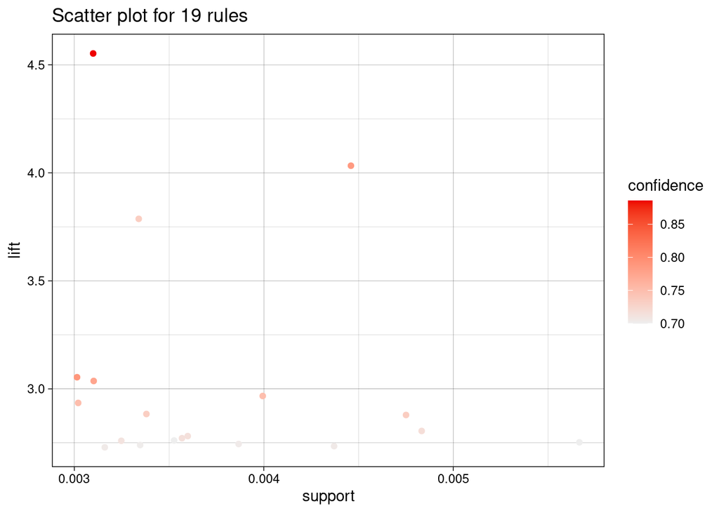

```r
plot(rulesApriori, measure = c("support", "lift"), shading = "confidence")
```

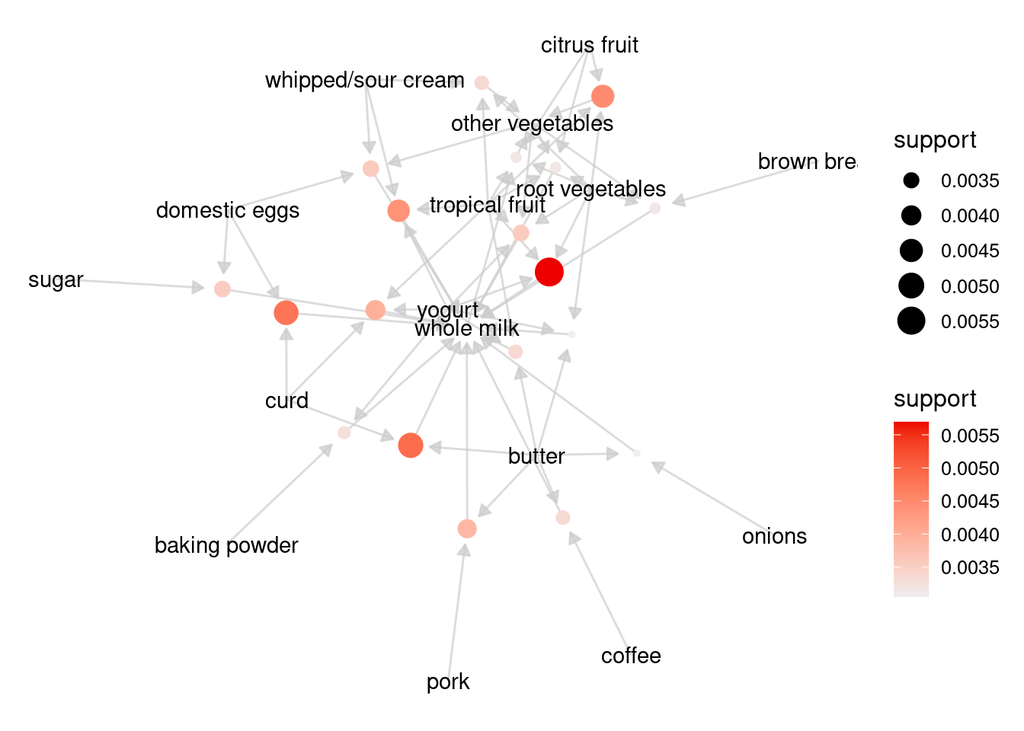

```r
plot(rulesApriori, method="graph", shading="support")
```

```r
plot(rulesApriori, method = "graph", engine = "htmlwidget", shading = "confidence")
```

[interactive chart not shown]

**OGÓLNE WNIOSKI:**

Wśród analizowanych reguł, poniższa reguła jest pod względem otrzymanych miar oceny reguł najlepsza:

15 >> LHS (citrus fruit,tropical fruit,root vegetables) => RHS (other vegetables) support 0.0044738 confidence 0.78571 lift 4.0607 count(“koszyki”) 44 certainty 0.73430

Wyboru dokonałem, ze względu na najlepszą kombinację parametrów tj. wysoki poziom wsparcia i współczynnika podniesienia przy wysokich wartościach zarówno zaufania jak również współczynnika pewności. Reguła ta nie jest najbardziej interesująca, jednak jest na pewno prawdziwa i sprawdzona. Nie bez powodu produkty te znajdują się przeważnie w bliskim położeniu względem siebie. Jeżeli, w przypadku tego sklepu tak nie było to ułożone ich w bliskim otoczeniu może pozytywnie wpłynąć na zakupy tych towarów przez kupujących. Z drugiej strony ta reguła może by samospełniającą się przepowiednią, czyli reguła, która wynika z tego, że produkty te leżą blisko siebie. W takiej sytuacji reguła ta jedynie potwierdza, że położenie to jest właściwe, ale nie wnosi nic nowego.

Reguły, które zakwalifikowałem jako ciekawe, to:  
- LHS(onions,butter) -> RHS(whole milk) support: 0.0030503 confidence: 0.75000 lift: 2.9352 certainty: 0.66420  
- LHS(tropical fruit,root vegetables,whipped/sour cream) -> RHS(other vegetables) support: 0.0034 confidence: 0.73333 lift 3.7900 count(“koszyki”) 33 certainty: 0.66936  
- LHS(citrus fruit,tropical fruit,root vegetables,whole milk) -> RHS(other vegetables) support: 0.0032 confidence: 0.88571 lift: 4.5775, count(“koszyki”): 31 certainty: 0.8583

Konkludując:  
Wśród wyselekcjonowanych reguł w ramach algorytmu Apriori o min. zaufaniu 0.7 i stosunkowo niewielkim wsparciu 0.003, otrzymaliśmy wiele połączeń produktów nabiałowych z produktami takimi jak warzywa i owoce, co sugeruje, że kategorie te powinny w ramach powierzchni sklepowej współsąsiadować w niedalekiej odległości, gazetki sklepowe mogą również być wykorzystane w ramach wzmocnienia sprzedaży tych produktów poprzez odpowiednie strategie sprzedażowe (rabaty, zestawy, promocje itd.).

**IV. WERYFIKACJA OTRZYMANYCH REGUŁ ALGORYTMEM ECLAT:**

```r
ecParam  = new("ECparameter", "confidence" = confidenceToUse, "support" = supportToUse, "minlen" = 2)
itemsets <- eclat(Groceries, ecParam)
```

```
## Eclat
##
## parameter specification:
##  tidLists support minlen maxlen            target  ext
##     FALSE   0.003      2     10 frequent itemsets TRUE
##
## algorithmic control:
##  sparse sort verbose
##       7   -2    TRUE
##
## Absolute minimum support count: 29
##
## create itemset ...
## set transactions ...[169 item(s), 9835 transaction(s)] done [0.00s].
## sorting and recoding items ... [136 item(s)] done [0.00s].
## creating sparse bit matrix ... [136 row(s), 9835 column(s)] done [0.00s].
## writing  ... [2090 set(s)] done [0.02s].
## Creating S4 object  ... done [0.00s].
```

```r
rulesEclat <- ruleInduction(itemsets, Groceries, confidence=confidenceToUse)
inspect(rulesEclat)
```

```
##      lhs                     rhs                  support confidence   lift itemset
## [1]  {yogurt,
##       baking powder}      => {whole milk}       0.0032537    0.71111 2.7830     150
## [2]  {onions,
##       butter}             => {whole milk}       0.0030503    0.75000 2.9352     449
## [3]  {domestic eggs,
##       sugar}              => {whole milk}       0.0035587    0.71429 2.7955     606
## [4]  {butter,
##       coffee}             => {whole milk}       0.0033554    0.70213 2.7479     959
## [5]  {butter,
##       curd}               => {whole milk}       0.0048805    0.71642 2.8038    1109
## [6]  {curd,
##       domestic eggs}      => {whole milk}       0.0047789    0.73438 2.8741    1111
## [7]  {tropical fruit,
##       curd,
##       yogurt}             => {whole milk}       0.0039654    0.75000 2.9352    1129
## [8]  {pork,
##       butter}             => {whole milk}       0.0038638    0.70370 2.7540    1219
## [9]  {root vegetables,
##       other vegetables,
##       brown bread}        => {whole milk}       0.0031520    0.77500 3.0331    1371
## [10] {tropical fruit,
##       butter,
##       yogurt}             => {whole milk}       0.0033554    0.73333 2.8700    1481
## [11] {root vegetables,
##       butter,
##       yogurt}             => {whole milk}       0.0030503    0.78947 3.0897    1488
## [12] {other vegetables,
##       whipped/sour cream,
##       domestic eggs}      => {whole milk}       0.0035587    0.70000 2.7396    1570
## [13] {tropical fruit,
##       root vegetables,
##       whipped/sour cream} => {other vegetables} 0.0033554    0.73333 3.7900    1707
## [14] {tropical fruit,
##       yogurt,
##       whipped/sour cream} => {whole milk}       0.0043721    0.70492 2.7588    1708
## [15] {citrus fruit,
##       tropical fruit,
##       root vegetables,
##       whole milk}         => {other vegetables} 0.0031520    0.88571 4.5775    1865
## [16] {citrus fruit,
##       tropical fruit,
##       root vegetables,
##       other vegetables}   => {whole milk}       0.0031520    0.70455 2.7573    1865
## [17] {citrus fruit,
##       tropical fruit,
##       root vegetables}    => {other vegetables} 0.0044738    0.78571 4.0607    1867
## [18] {tropical fruit,
##       root vegetables,
##       other vegetables,
##       yogurt}             => {whole milk}       0.0035587    0.71429 2.7955    2014
## [19] {tropical fruit,
##       root vegetables,
##       yogurt}             => {whole milk}       0.0056940    0.70000 2.7396    2015
```

```r
#seleckcja zbiorów wykrytych przy użyciu funkcji eclat, a nie wykrytych przy użyciu funkcji apriori
inspect(rulesEclat[which(!(rulesEclat %in% rulesApriori))])
print(rulesEclat[which(!(rulesEclat %in% rulesApriori))])
```

```
## set of 0 rules
```

#########################################KONIEC SKRYPTU#########################################